# 360-HW3

Safiye Şahin

10 01 2021

## Data

The first part of the data block and time series object data can be examined below. After examining the movement of the housing sales data on the graph , the log of the data was taken to prevent the increasing variance and continued as such.

```
## # A tibble: 6 x 9
##   Date    Total_Sales   USD  EURO interest  prob economic_level unemp   car
##   <chr>         <dbl> <dbl> <dbl>    <dbl> <dbl>          <dbl> <dbl> <dbl>
## 1 2013-01       87444  1.76  2.34     9.78  10.7           75.4  91.0  11.2
## 2 2013-02       88519  1.77  2.37     9.58  10.5           75.0  91.6  10.4
## 3 2013-03       97956  1.81  2.34     9.31  11.3           74.6  85.9  11.9
## 4 2013-04       95381  1.80  2.34     9.06  10.6           76.1  87.4  11.3
## 5 2013-05      103261  1.82  2.37     8.77  10.2           76.8  85.4  14.8
## 6 2013-06       96424  1.89  2.50     8.30  11.6           76.0  84.1  13.4
```

```
##         Jan    Feb    Mar    Apr    May    Jun
## 2013  87444  88519  97956  95381 103261  96424
```

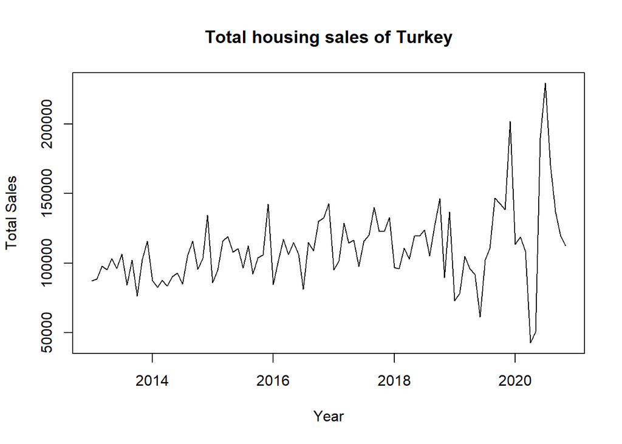

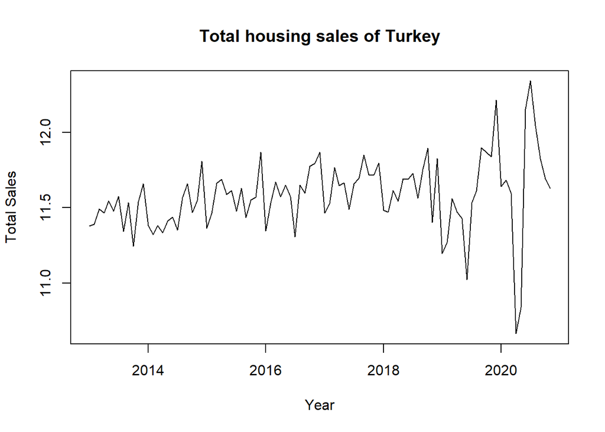

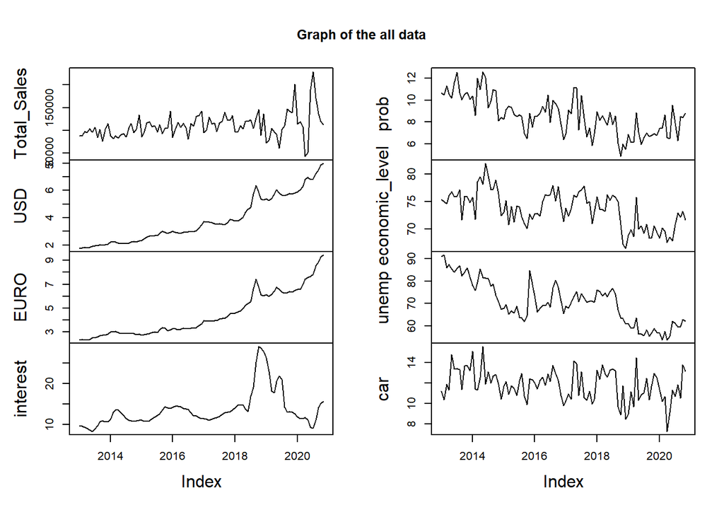

## Correlation

A correlation matrix was made to see how relevant the data, thought to be related to total home sales, but we did not find a limit that closely resembles our actual data.

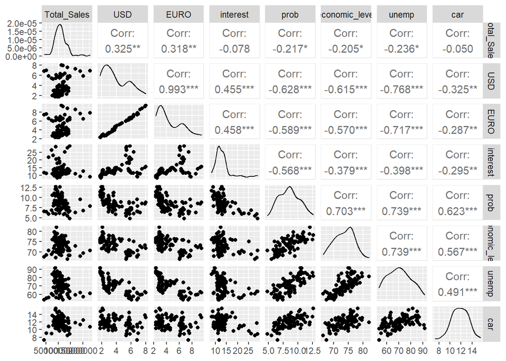

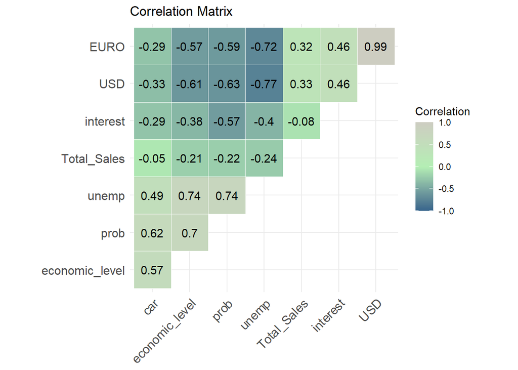

## Regression and Examination of residuals

While performing the regression analysis of the available data, firstly the moon factor was added. The trend in residuals was observed and the trend factor was added in the next step. Later, the boxplot of the data was drawn, outliers were determined and a relevant outlier data was added.

```
##
## Call:
## lm(formula = log_sales ~ -1 + as.factor(month), data = sales)
##
## Residuals:
##      Min       1Q   Median       3Q      Max
## -0.76004 -0.08423  0.00389  0.10789  0.72069
##
## Coefficients:
##                    Estimate Std. Error t value Pr(>|t|)
## as.factor(month)1  11.40691    0.07920   144.0   <2e-16 ***
## as.factor(month)2  11.45731    0.07920   144.7   <2e-16 ***
## as.factor(month)3  11.59349    0.07920   146.4   <2e-16 ***
## as.factor(month)4  11.42394    0.07920   144.2   <2e-16 ***
## as.factor(month)5  11.47778    0.07920   144.9   <2e-16 ***
## as.factor(month)6  11.55767    0.07920   145.9   <2e-16 ***
## as.factor(month)7  11.62235    0.07920   146.7   <2e-16 ***
## as.factor(month)8  11.63899    0.07920   146.9   <2e-16 ***
## as.factor(month)9  11.69469    0.07920   147.7   <2e-16 ***
## as.factor(month)10 11.65211    0.07920   147.1   <2e-16 ***
## as.factor(month)11 11.63070    0.07920   146.8   <2e-16 ***
## as.factor(month)12 11.86390    0.08467   140.1   <2e-16 ***
## ---
## Signif. codes:  0 '***' 0.001 '**' 0.01 '*' 0.05 '.' 0.1 ' ' 1
##
## Residual standard error: 0.224 on 83 degrees of freedom
## Multiple R-squared:  0.9997, Adjusted R-squared:  0.9996
## F-statistic: 2.116e+04 on 12 and 83 DF,  p-value: < 2.2e-16
```

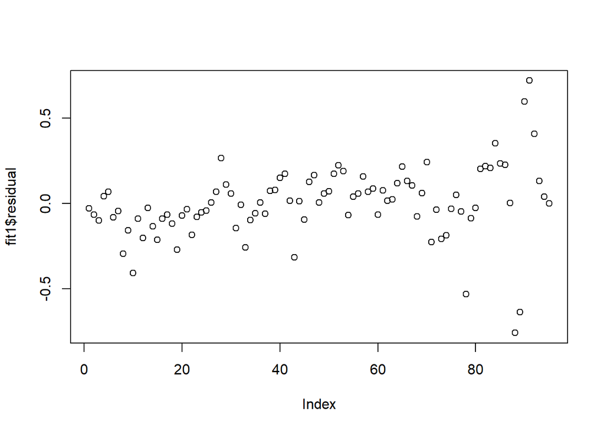

```
##
## Call:
## lm(formula = log_sales ~ -1 + as.factor(month) + trend, data = sales)
##
## Residuals:
##      Min       1Q   Median       3Q      Max
## -0.85104 -0.08588  0.02453  0.10132  0.62969
##
## Coefficients:
##                     Estimate Std. Error t value Pr(>|t|)
## as.factor(month)1  11.313741   0.084084 134.553  < 2e-16 ***
## as.factor(month)2  11.361980   0.084426 134.579  < 2e-16 ***
## as.factor(month)3  11.495990   0.084775 135.607  < 2e-16 ***
## as.factor(month)4  11.324271   0.085129 133.024  < 2e-16 ***
## as.factor(month)5  11.375950   0.085491 133.067  < 2e-16 ***
## as.factor(month)6  11.453671   0.085858 133.402  < 2e-16 ***
## as.factor(month)7  11.516180   0.086232 133.550  < 2e-16 ***
## as.factor(month)8  11.530662   0.086611 133.131  < 2e-16 ***
## as.factor(month)9  11.584193   0.086997 133.157  < 2e-16 ***
## as.factor(month)10 11.539442   0.087388 132.048  < 2e-16 ***
## as.factor(month)11 11.515873   0.087785 131.182  < 2e-16 ***
## as.factor(month)12 11.759902   0.090590 129.814  < 2e-16 ***
## trend               0.002167   0.000814   2.662  0.00936 **
## ---
## Signif. codes:  0 '***' 0.001 '**' 0.01 '*' 0.05 '.' 0.1 ' ' 1
##
## Residual standard error: 0.2162 on 82 degrees of freedom
## Multiple R-squared:  0.9997, Adjusted R-squared:  0.9997
## F-statistic: 2.097e+04 on 13 and 82 DF,  p-value: < 2.2e-16
```

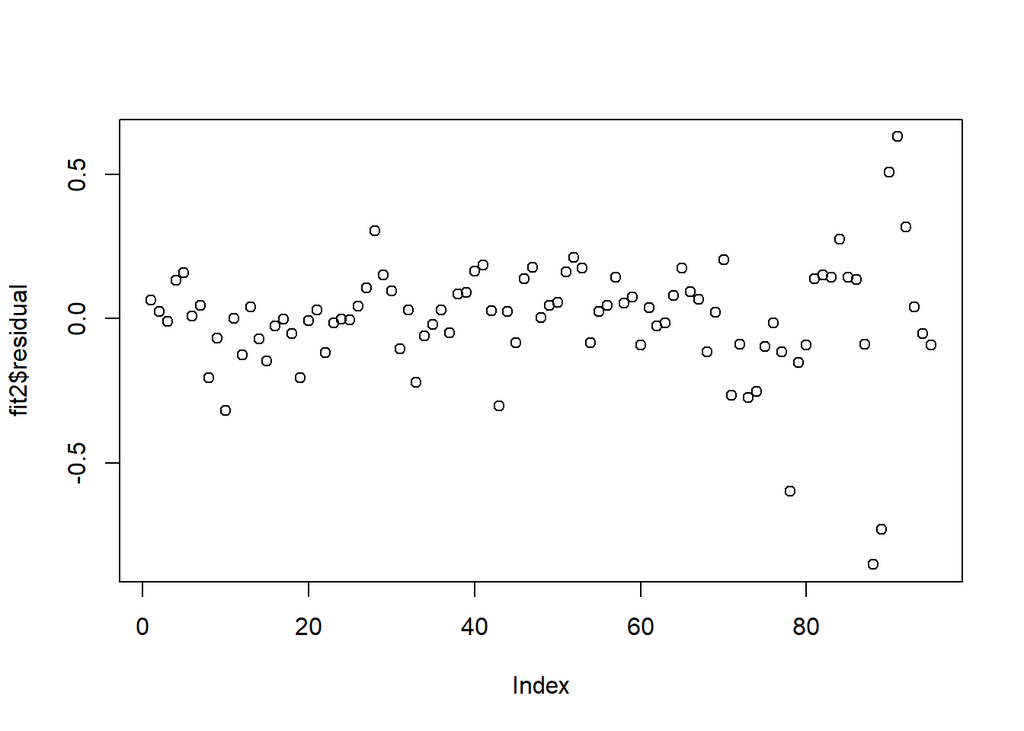

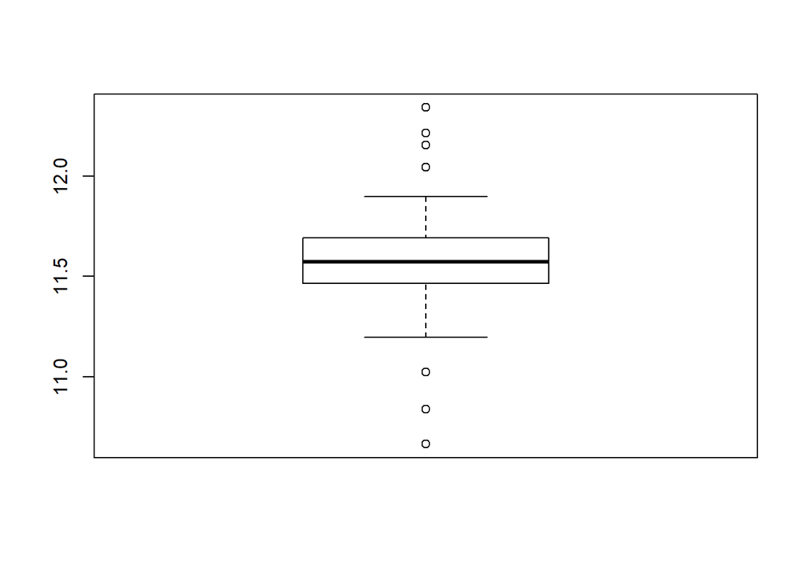

```
##
## Call:
## lm(formula = log_sales ~ -1 + as.factor(month) + trend + outliers,
##     data = sales)
##
## Residuals:
##      Min       1Q   Median       3Q      Max
## -0.78359 -0.10537  0.01414  0.10361  0.69714
##
## Coefficients:
##                      Estimate Std. Error t value Pr(>|t|)
## as.factor(month)1  11.2977779  0.0857566 131.742  < 2e-16 ***
## as.factor(month)2  11.3456459  0.0861681 131.669  < 2e-16 ***
## as.factor(month)3  11.4792850  0.0865870 132.575  < 2e-16 ***
## as.factor(month)4  11.3190576  0.0853446 132.628  < 2e-16 ***
## as.factor(month)5  11.3703650  0.0857307 132.629  < 2e-16 ***
## as.factor(month)6  11.4595788  0.0861209 133.064  < 2e-16 ***
## as.factor(month)7  11.5098531  0.0865259 133.022  < 2e-16 ***
## as.factor(month)8  11.5239639  0.0869348 132.559  < 2e-16 ***
## as.factor(month)9  11.5652600  0.0892509 129.581  < 2e-16 ***
## as.factor(month)10 11.5201376  0.0897190 128.402  < 2e-16 ***
## as.factor(month)11 11.4961973  0.0901936 127.461  < 2e-16 ***
## as.factor(month)12 11.7556410  0.0907435 129.548  < 2e-16 ***
## trend               0.0025379  0.0009018   2.814  0.00613 **
## outliers           -0.0949061  0.0989784  -0.959  0.34048
## ---
## Signif. codes:  0 '***' 0.001 '**' 0.01 '*' 0.05 '.' 0.1 ' ' 1
##
## Residual standard error: 0.2163 on 81 degrees of freedom
## Multiple R-squared:  0.9997, Adjusted R-squared:  0.9997
## F-statistic: 1.945e+04 on 14 and 81 DF,  p-value: < 2.2e-16
```

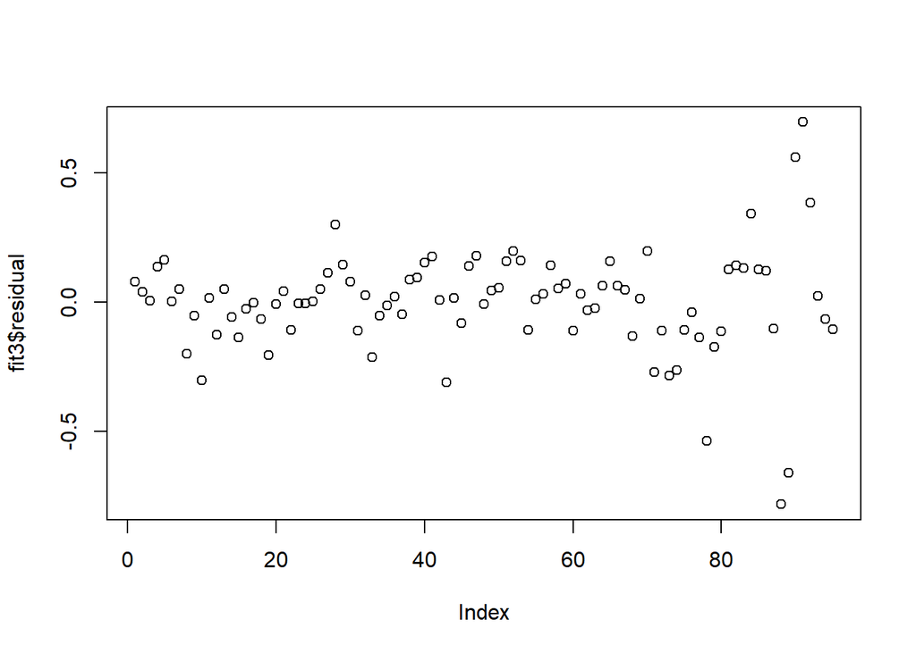

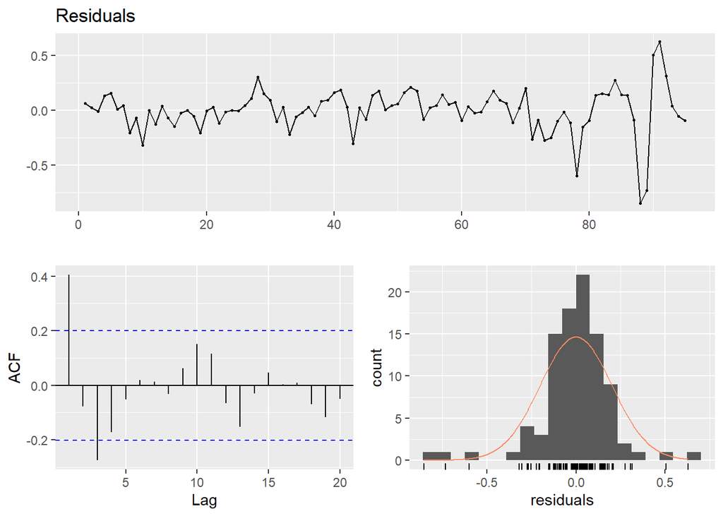

```
##
##  Breusch-Godfrey test for serial correlation of order up to 12
##
## data:  Residuals
## LM test = 34.864, df = 12, p-value = 0.0004923
```

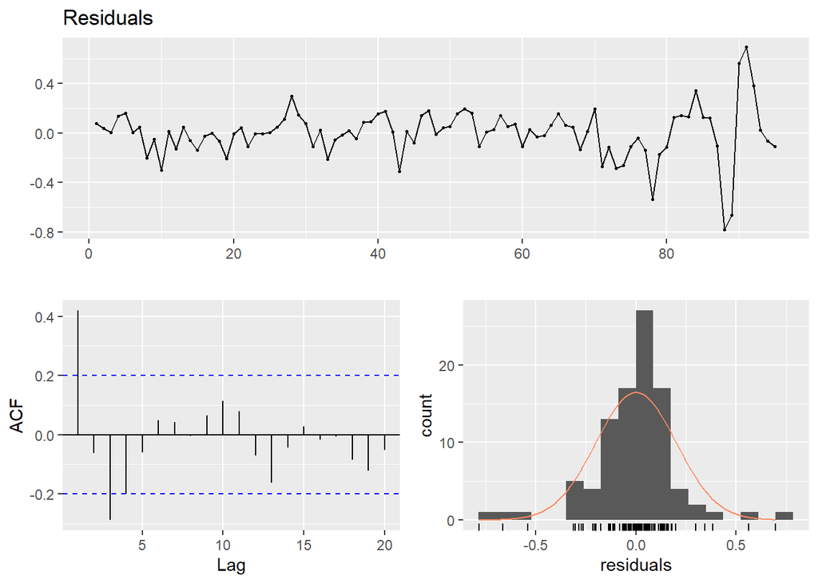

```
##
##  Breusch-Godfrey test for serial correlation of order up to 12
##
## data:  Residuals
## LM test = 33.598, df = 12, p-value = 0.0007803
```

While the residual standard error decreases in the first two steps, it is seen that the added outlier data increases this error slightly, and when the residuals of the model in the second step and the model in the third step are compared, it appears that the added outlier data increases the p-value and it is decided to remain in the model for now.

The USD ratio with the highest correlation is added to the model as an independent variable as the “money” variable, but it does not seem to be very important in the model. In order to make it more important, the distribution of residuals according to the money variable is examined in table 2 and this variable is added to the dataset in three parts as a result of the some manipulation, although a decrease in the res. std.error of the obtained model is observed, money variables still do not seem important.Therefore, it will not be used in other stages of the model.

```
##
## Call:
## lm(formula = log_sales ~ -1 + as.factor(month) + trend + outliers +
##     money, data = sales)
##
## Residuals:
##      Min       1Q   Median       3Q      Max
## -0.77667 -0.08552  0.00313  0.09009  0.69975
##
## Coefficients:
##                     Estimate Std. Error t value Pr(>|t|)
## as.factor(month)1  11.360542   0.099672 113.979   <2e-16 ***
## as.factor(month)2  11.405394   0.098786 115.456   <2e-16 ***
## as.factor(month)3  11.540596   0.099783 115.657   <2e-16 ***
## as.factor(month)4  11.378184   0.097821 116.316   <2e-16 ***
## as.factor(month)5  11.431965   0.099165 115.282   <2e-16 ***
## as.factor(month)6  11.512343   0.096056 119.850   <2e-16 ***
## as.factor(month)7  11.565546   0.097509 118.610   <2e-16 ***
## as.factor(month)8  11.587198   0.100877 114.864   <2e-16 ***
## as.factor(month)9  11.638978   0.107418 108.352   <2e-16 ***
## as.factor(month)10 11.591995   0.106965 108.372   <2e-16 ***
## as.factor(month)11 11.564543   0.105822 109.283   <2e-16 ***
## as.factor(month)12 11.805880   0.099328 118.858   <2e-16 ***
## trend               0.005729   0.002756   2.079   0.0408 *
## outliers           -0.053690   0.104253  -0.515   0.6080
## money              -0.056914   0.046464  -1.225   0.2242
## ---
## Signif. codes:  0 '***' 0.001 '**' 0.01 '*' 0.05 '.' 0.1 ' ' 1
##
## Residual standard error: 0.2157 on 80 degrees of freedom
## Multiple R-squared:  0.9997, Adjusted R-squared:  0.9997
## F-statistic: 1.827e+04 on 15 and 80 DF,  p-value: < 2.2e-16
```

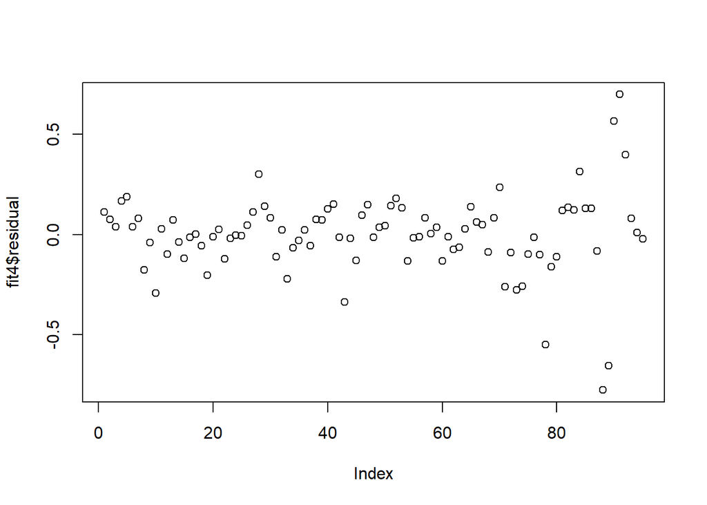

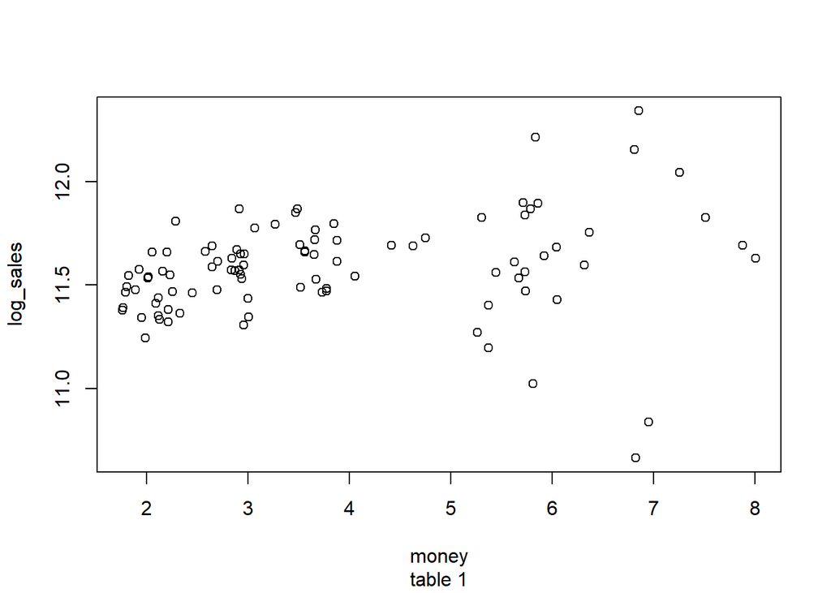

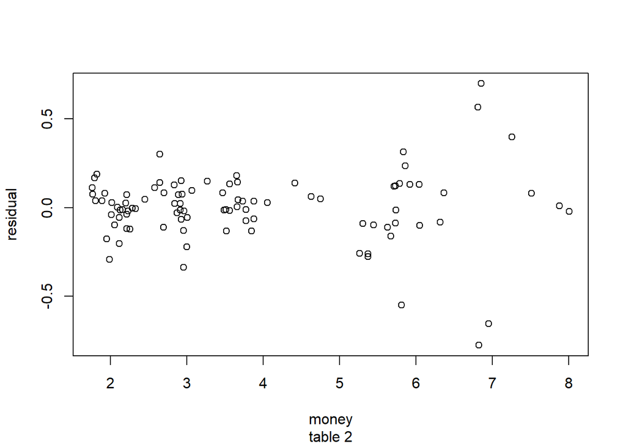

```
##
## Call:
## lm(formula = log_sales ~ -1 + as.factor(month) + trend + outliers +
##     moneyp1 + moneyp2 + moneyp3, data = sales)
##
## Residuals:
##      Min       1Q   Median       3Q      Max
## -0.77823 -0.07458  0.00118  0.09064  0.70691
##
## Coefficients:
##                     Estimate Std. Error t value Pr(>|t|)
## as.factor(month)1  11.190978   0.149988  74.613   <2e-16 ***
## as.factor(month)2  11.239039   0.148571  75.648   <2e-16 ***
## as.factor(month)3  11.370184   0.153430  74.107   <2e-16 ***
## as.factor(month)4  11.202699   0.155749  71.928   <2e-16 ***
## as.factor(month)5  11.250632   0.161977  69.458   <2e-16 ***
## as.factor(month)6  11.335256   0.153233  73.974   <2e-16 ***
## as.factor(month)7  11.389096   0.156899  72.588   <2e-16 ***
## as.factor(month)8  11.409389   0.145356  78.493   <2e-16 ***
## as.factor(month)9  11.452490   0.158313  72.341   <2e-16 ***
## as.factor(month)10 11.408833   0.151411  75.350   <2e-16 ***
## as.factor(month)11 11.385103   0.146168  77.891   <2e-16 ***
## as.factor(month)12 11.644299   0.143656  81.057   <2e-16 ***
## trend               0.002205   0.003071   0.718    0.475
## outliers           -0.059927   0.123548  -0.485    0.629
## moneyp1             0.049001   0.076261   0.643    0.522
## moneyp2             0.002265   0.010205   0.222    0.825
## moneyp3             1.527014   3.204246   0.477    0.635
## ---
## Signif. codes:  0 '***' 0.001 '**' 0.01 '*' 0.05 '.' 0.1 ' ' 1
##
## Residual standard error: 0.2154 on 78 degrees of freedom
## Multiple R-squared:  0.9997, Adjusted R-squared:  0.9997
## F-statistic: 1.616e+04 on 17 and 78 DF,  p-value: < 2.2e-16
```

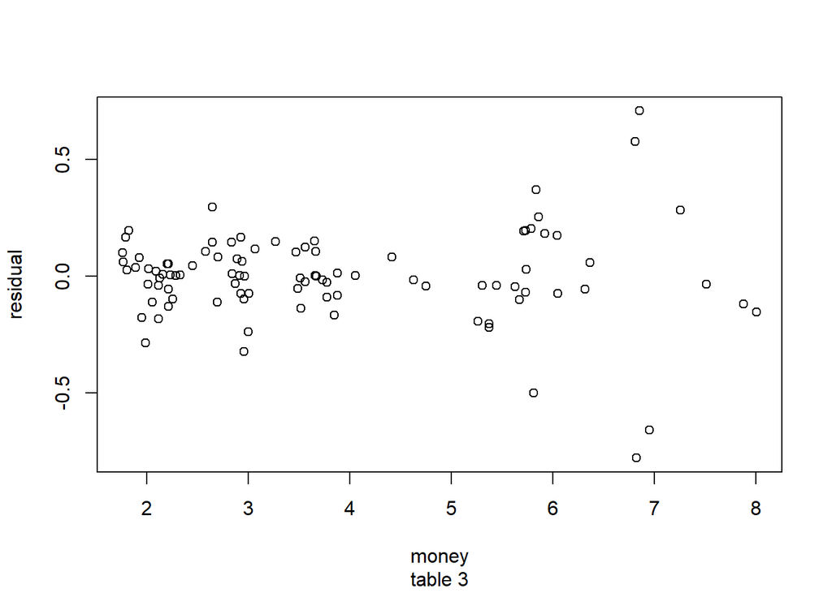

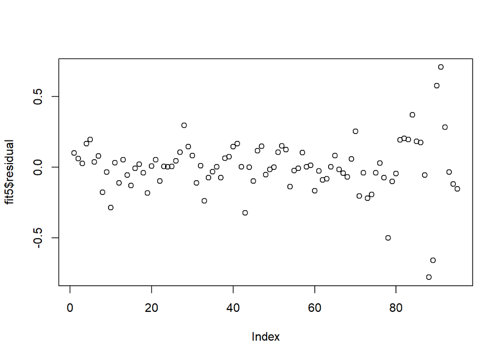

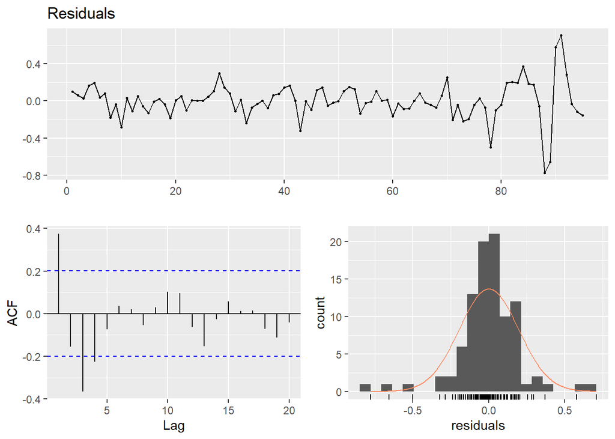

```
##
##  Breusch-Godfrey test for serial correlation of order up to 12
##
## data:  Residuals
## LM test = 37.153, df = 12, p-value = 0.000211
```

After examining all the data that can be added to the model as an independent variable, the best developed version was selected and some of the improvements made are shown below. However, when residuals are checked later, it is seen that the desired success is still not achieved in the autocorrelation function.

```
##
## Call:
## lm(formula = log_sales ~ -1 + as.factor(month) + trend + unemp,
##     data = sales)
##
## Residuals:
##      Min       1Q   Median       3Q      Max
## -0.81803 -0.08176  0.00597  0.11323  0.61907
##
## Coefficients:
##                     Estimate Std. Error t value Pr(>|t|)
## as.factor(month)1  10.863264   0.338073  32.133  < 2e-16 ***
## as.factor(month)2  10.919264   0.332694  32.821  < 2e-16 ***
## as.factor(month)3  11.051918   0.333735  33.116  < 2e-16 ***
## as.factor(month)4  10.868957   0.341738  31.805  < 2e-16 ***
## as.factor(month)5  10.927118   0.337264  32.399  < 2e-16 ***
## as.factor(month)6  10.998170   0.342050  32.154  < 2e-16 ***
## as.factor(month)7  11.060761   0.342085  32.333  < 2e-16 ***
## as.factor(month)8  11.072130   0.344371  32.152  < 2e-16 ***
## as.factor(month)9  11.133086   0.339244  32.817  < 2e-16 ***
## as.factor(month)10 11.088411   0.339290  32.681  < 2e-16 ***
## as.factor(month)11 11.053584   0.347308  31.826  < 2e-16 ***
## as.factor(month)12 11.317119   0.334341  33.849  < 2e-16 ***
## trend               0.003678   0.001365   2.695  0.00857 **
## unemp               0.005382   0.003914   1.375  0.17285
## ---
## Signif. codes:  0 '***' 0.001 '**' 0.01 '*' 0.05 '.' 0.1 ' ' 1
##
## Residual standard error: 0.2151 on 81 degrees of freedom
## Multiple R-squared:  0.9997, Adjusted R-squared:  0.9997
## F-statistic: 1.968e+04 on 14 and 81 DF,  p-value: < 2.2e-16
```

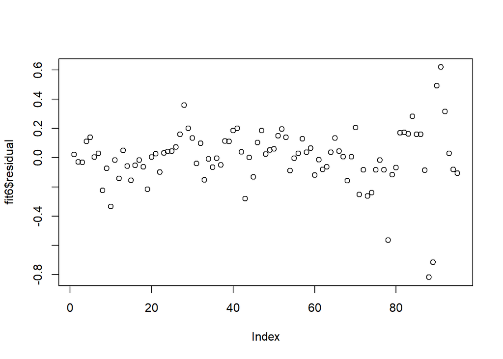

```
##
## Call:
## lm(formula = log_sales ~ -1 + as.factor(month) + trend + unemp +
##     car, data = sales)
##
## Residuals:
##      Min       1Q   Median       3Q      Max
## -0.70823 -0.09134  0.00644  0.10831  0.65393
##
## Coefficients:
##                     Estimate Std. Error t value Pr(>|t|)
## as.factor(month)1  10.721158   0.343626  31.200   <2e-16 ***
## as.factor(month)2  10.787306   0.337119  31.998   <2e-16 ***
## as.factor(month)3  10.916566   0.338561  32.244   <2e-16 ***
## as.factor(month)4  10.715765   0.348684  30.732   <2e-16 ***
## as.factor(month)5  10.760177   0.346496  31.054   <2e-16 ***
## as.factor(month)6  10.851217   0.348103  31.172   <2e-16 ***
## as.factor(month)7  10.897874   0.350451  31.097   <2e-16 ***
## as.factor(month)8  10.906304   0.353076  30.889   <2e-16 ***
## as.factor(month)9  11.007229   0.342676  32.121   <2e-16 ***
## as.factor(month)10 10.940496   0.345593  31.657   <2e-16 ***
## as.factor(month)11 10.901707   0.353826  30.811   <2e-16 ***
## as.factor(month)12 11.190337   0.338057  33.102   <2e-16 ***
## trend               0.003412   0.001356   2.515   0.0139 *
## unemp               0.002433   0.004217   0.577   0.5656
## car                 0.031065   0.017776   1.748   0.0844 .
## ---
## Signif. codes:  0 '***' 0.001 '**' 0.01 '*' 0.05 '.' 0.1 ' ' 1
##
## Residual standard error: 0.2124 on 80 degrees of freedom
## Multiple R-squared:  0.9997, Adjusted R-squared:  0.9997
## F-statistic: 1.884e+04 on 15 and 80 DF,  p-value: < 2.2e-16
```

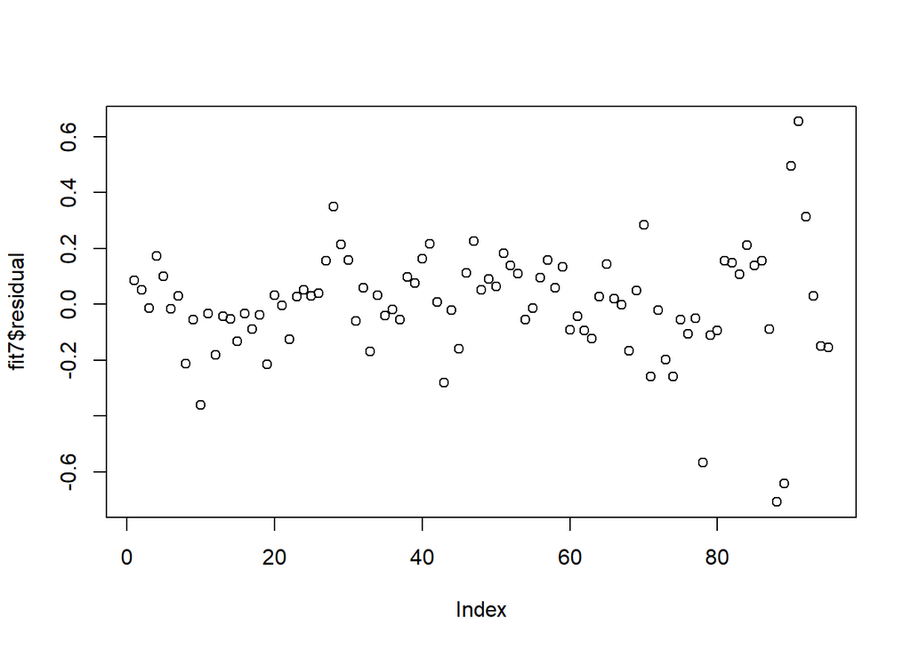

```
##
## Call:
## lm(formula = log_sales ~ -1 + as.factor(month) + trend + outliers +
##     unemp + int + car, data = sales)
##
## Residuals:
##      Min       1Q   Median       3Q      Max
## -0.72393 -0.06078  0.00391  0.07781  0.63067
##
## Coefficients:
##                     Estimate Std. Error t value Pr(>|t|)
## as.factor(month)1  11.065305   0.349748  31.638  < 2e-16 ***
## as.factor(month)2  11.119505   0.342500  32.466  < 2e-16 ***
## as.factor(month)3  11.238045   0.342666  32.796  < 2e-16 ***
## as.factor(month)4  11.065193   0.355417  31.133  < 2e-16 ***
## as.factor(month)5  11.113701   0.353914  31.402  < 2e-16 ***
## as.factor(month)6  11.211368   0.356832  31.419  < 2e-16 ***
## as.factor(month)7  11.250239   0.357321  31.485  < 2e-16 ***
## as.factor(month)8  11.253678   0.359170  31.332  < 2e-16 ***
## as.factor(month)9  11.335551   0.347083  32.659  < 2e-16 ***
## as.factor(month)10 11.288952   0.351949  32.076  < 2e-16 ***
## as.factor(month)11 11.251827   0.359604  31.289  < 2e-16 ***
## as.factor(month)12 11.551334   0.346989  33.290  < 2e-16 ***
## trend               0.004943   0.001414   3.496 0.000782 ***
## outliers           -0.156279   0.101527  -1.539 0.127782
## unemp               0.002225   0.004050   0.549 0.584349
## int                -0.017670   0.006063  -2.915 0.004645 **
## car                 0.018119   0.017753   1.021 0.310598
## ---
## Signif. codes:  0 '***' 0.001 '**' 0.01 '*' 0.05 '.' 0.1 ' ' 1
##
## Residual standard error: 0.2039 on 78 degrees of freedom
## Multiple R-squared:  0.9997, Adjusted R-squared:  0.9997
## F-statistic: 1.804e+04 on 17 and 78 DF,  p-value: < 2.2e-16
```

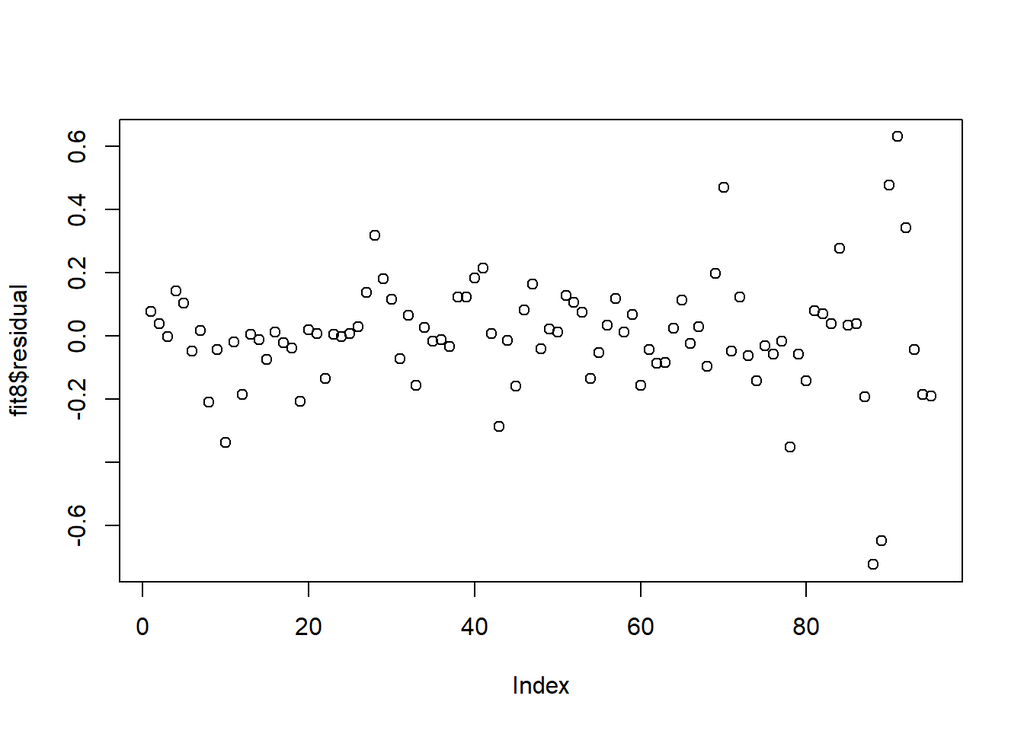

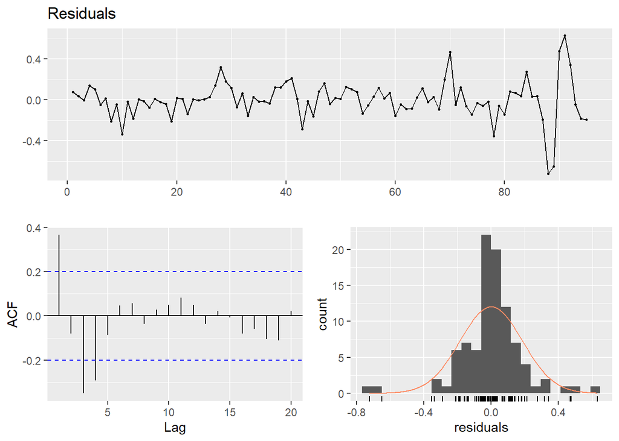

```
##
##  Breusch-Godfrey test for serial correlation of order up to 20
##
## data:  Residuals
## LM test = 41.319, df = 20, p-value = 0.003389
```

The lag of residuels was added to the model to improve the correlation function.In addition, outlier data, which was considered insignificant, was removed from the model at this stage.

```
##
## Call:
## lm(formula = log_sales ~ -1 + as.factor(month) + trend + unemp +
##     int + car + lagnew, data = sales_new)
##
## Residuals:
##      Min       1Q   Median       3Q      Max
## -0.72728 -0.07660  0.01947  0.08493  0.65017
##
## Coefficients:
##                     Estimate Std. Error t value Pr(>|t|)
## as.factor(month)1  10.925584   0.323763  33.746  < 2e-16 ***
## as.factor(month)2  10.991380   0.318044  34.559  < 2e-16 ***
## as.factor(month)3  11.111091   0.318418  34.895  < 2e-16 ***
## as.factor(month)4  10.914195   0.327568  33.319  < 2e-16 ***
## as.factor(month)5  10.963198   0.325772  33.653  < 2e-16 ***
## as.factor(month)6  11.043419   0.326586  33.815  < 2e-16 ***
## as.factor(month)7  11.099767   0.329269  33.710  < 2e-16 ***
## as.factor(month)8  11.103354   0.331156  33.529  < 2e-16 ***
## as.factor(month)9  11.210306   0.322952  34.712  < 2e-16 ***
## as.factor(month)10 11.160197   0.326731  34.157  < 2e-16 ***
## as.factor(month)11 11.120463   0.333944  33.300  < 2e-16 ***
## as.factor(month)12 11.392073   0.319764  35.627  < 2e-16 ***
## trend               0.004545   0.001273   3.570 0.000620 ***
## unemp               0.003275   0.003919   0.836 0.405936
## int                -0.015675   0.005382  -2.913 0.004688 **
## car                 0.022136   0.016608   1.333 0.186498
## lagnew              0.393851   0.108089   3.644 0.000485 ***
## ---
## Signif. codes:  0 '***' 0.001 '**' 0.01 '*' 0.05 '.' 0.1 ' ' 1
##
## Residual standard error: 0.1922 on 77 degrees of freedom
## Multiple R-squared:  0.9998, Adjusted R-squared:  0.9997
## F-statistic: 2.008e+04 on 17 and 77 DF,  p-value: < 2.2e-16
```

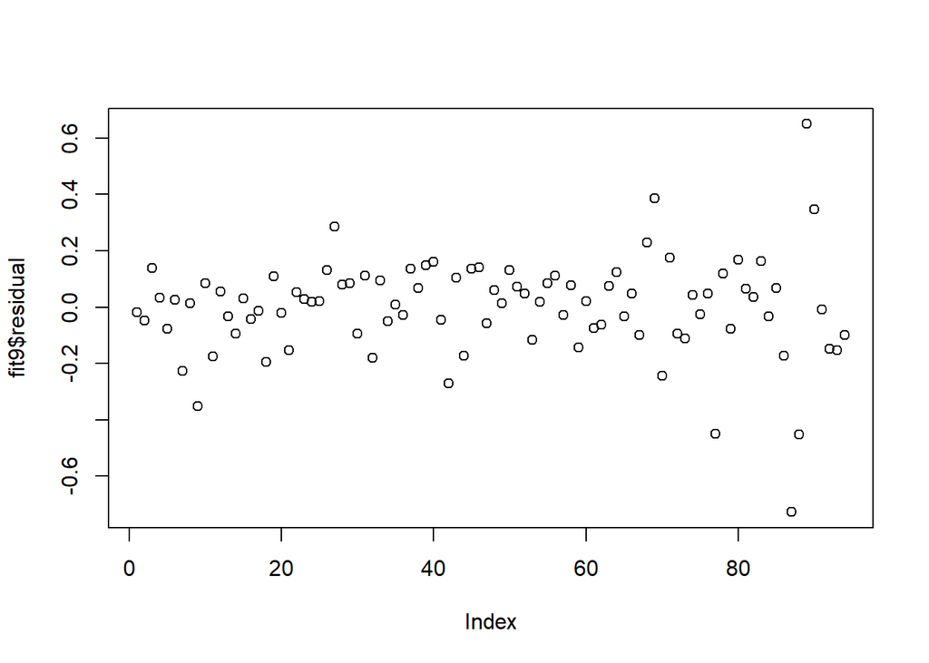

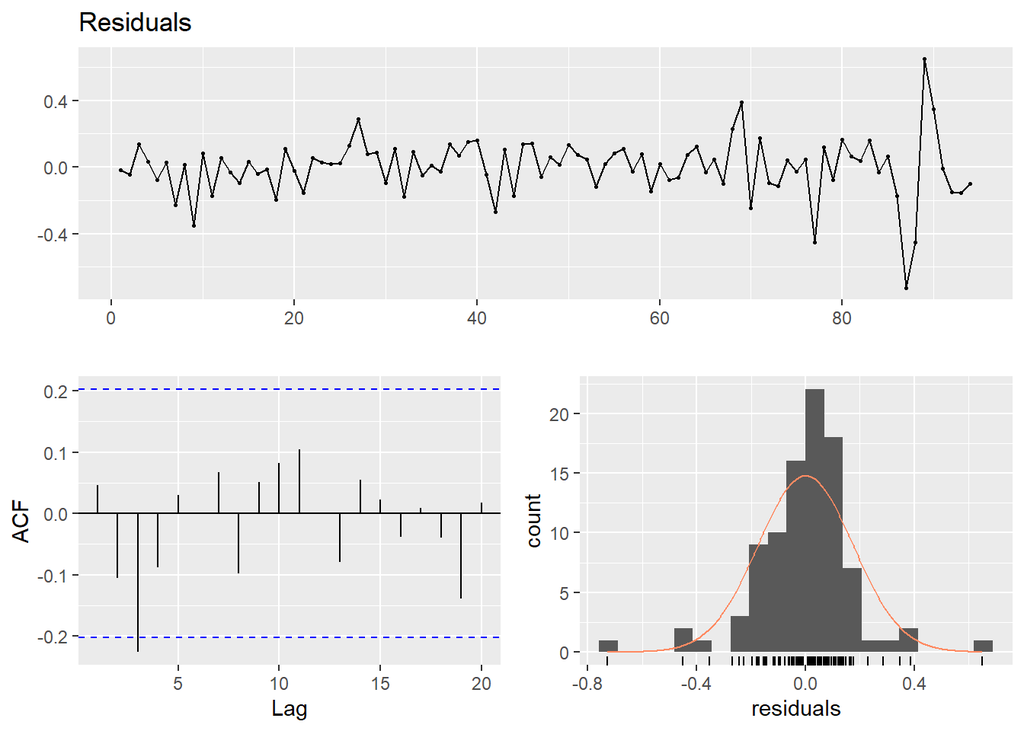

```
##
##  Breusch-Godfrey test for serial correlation of order up to 20
##
## data:  Residuals
## LM test = 29.291, df = 20, p-value = 0.08219
```

Quantile variables are added to obtain corrections in the residual graph examined at each stage and the resulting model is both reduced res. std. errors and provided a better visual for residuals. And this is the final version of our model.

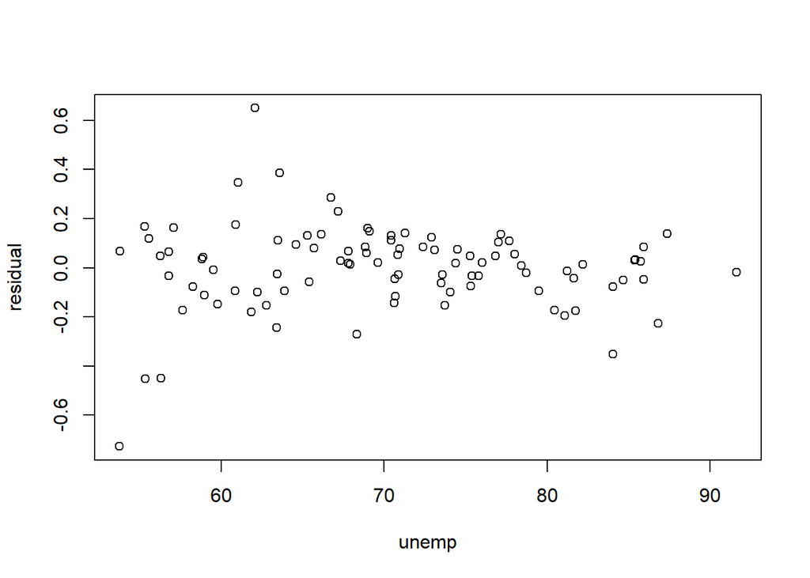

```
##
## Call:
## lm(formula = log_sales ~ -1 + as.factor(month) + trend + unemp +
##     int + car + lagnew + small_outlier + large_outlier, data = sales_new)
##
## Residuals:
##      Min       1Q   Median       3Q      Max
## -0.28575 -0.05470  0.01340  0.06478  0.21496
##
## Coefficients:
##                      Estimate Std. Error t value Pr(>|t|)
## as.factor(month)1  11.1609663  0.1855495  60.151  < 2e-16 ***
## as.factor(month)2  11.2163162  0.1822366  61.548  < 2e-16 ***
## as.factor(month)3  11.3346828  0.1825103  62.104  < 2e-16 ***
## as.factor(month)4  11.1344242  0.1913150  58.199  < 2e-16 ***
## as.factor(month)5  11.2249320  0.1895401  59.222  < 2e-16 ***
## as.factor(month)6  11.2990671  0.1897257  59.555  < 2e-16 ***
## as.factor(month)7  11.3625125  0.1914299  59.356  < 2e-16 ***
## as.factor(month)8  11.3405799  0.1900881  59.660  < 2e-16 ***
## as.factor(month)9  11.3613627  0.1862782  60.991  < 2e-16 ***
## as.factor(month)10 11.4242295  0.1895355  60.275  < 2e-16 ***
## as.factor(month)11 11.3625732  0.1913363  59.385  < 2e-16 ***
## as.factor(month)12 11.5366091  0.1848133  62.423  < 2e-16 ***
## trend               0.0042510  0.0007101   5.986 6.86e-08 ***
## unemp               0.0028121  0.0022023   1.277 0.205589
## int                -0.0203371  0.0030318  -6.708 3.26e-09 ***
## car                 0.0117884  0.0095062   1.240 0.218813
## lagnew              0.2295784  0.0626288   3.666 0.000458 ***
## small_outlier      -0.5129251  0.0566077  -9.061 1.14e-13 ***
## large_outlier       0.3054598  0.0411742   7.419 1.51e-10 ***
## ---
## Signif. codes:  0 '***' 0.001 '**' 0.01 '*' 0.05 '.' 0.1 ' ' 1
##
## Residual standard error: 0.1072 on 75 degrees of freedom
## Multiple R-squared:  0.9999, Adjusted R-squared:  0.9999
## F-statistic: 5.784e+04 on 19 and 75 DF,  p-value: < 2.2e-16
```

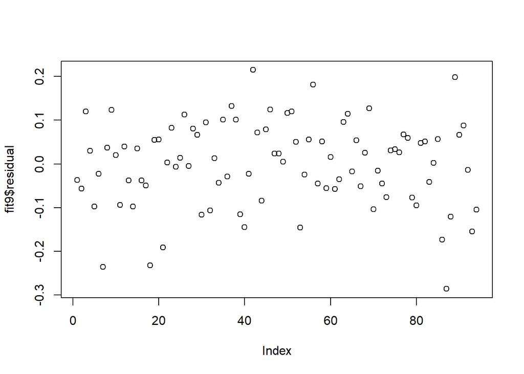

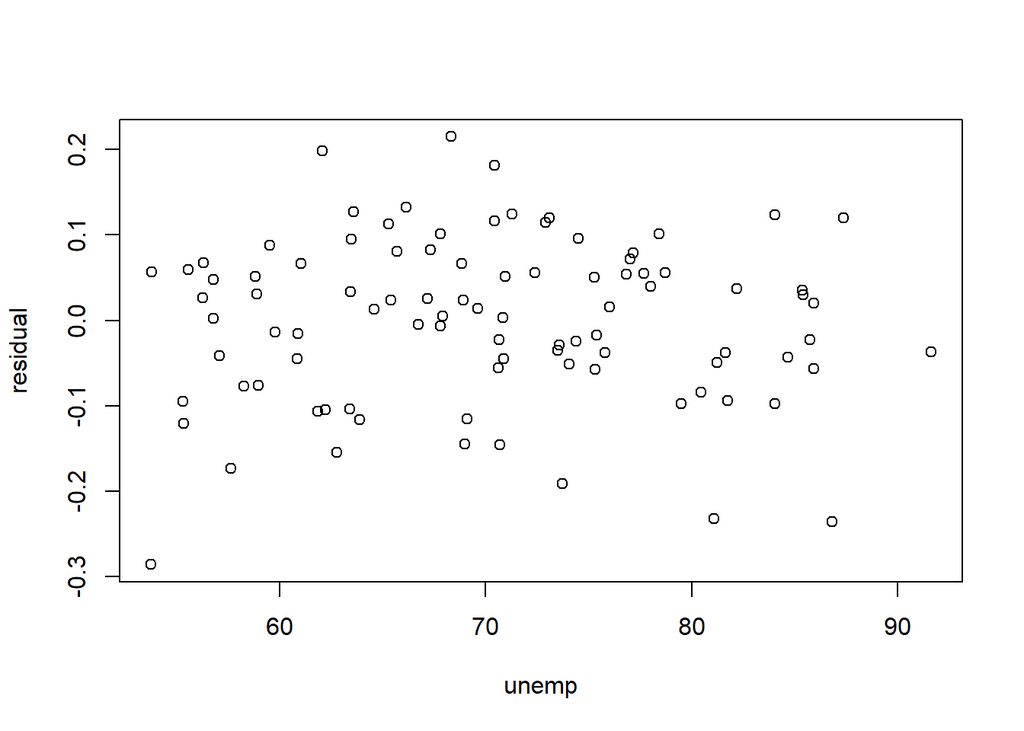

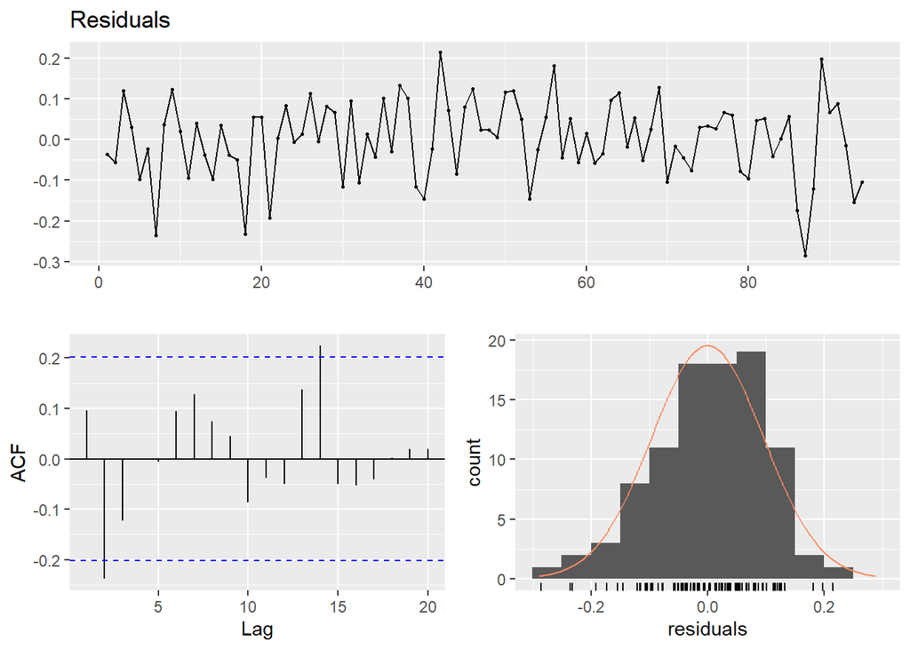

```
##
##  Breusch-Godfrey test for serial correlation of order up to 22
##
## data:  Residuals
## LM test = 22.608, df = 22, p-value = 0.4241
```